# A04

Olivia Martin

2022-09-28

**Instructions.** Change the author name on line 3 to be your name. Insert all requested answers. Upload in Moodle this file and a knitted file (html, doc, or pdf).

### Exercise 1 (5 points).

Answer from *Statistical Modeling: End-of-Chapter Exercises* by Daniel Kaplan the following.

**Read 5.1 (5 points).** What is a sampling distribution? What sort of variation does it reflect?

When you take multiple random samples of a population and calculate the same statistics with those different samples, you won’t get the same thing every time. For example, the mean height of students who took Math 323 in 2019-2020 is different from the mean height of the class before it, and neither is likely to be the mean of all students from all Math 323 classes. The sampling distribution measures the difference between those means. It reflects the variation inherent in taking different random samples from the same population.

### Exercise 2 (45 points).

Let the population be all runners in the 2005 Cherry Blossom 10 Mile Run as found in the `TenMileRace` data set.

1. (10 points) Obtain a density plot of the net race time (start to finish lines) grouped by sex for the entire population and for a random sample of 160 runners.

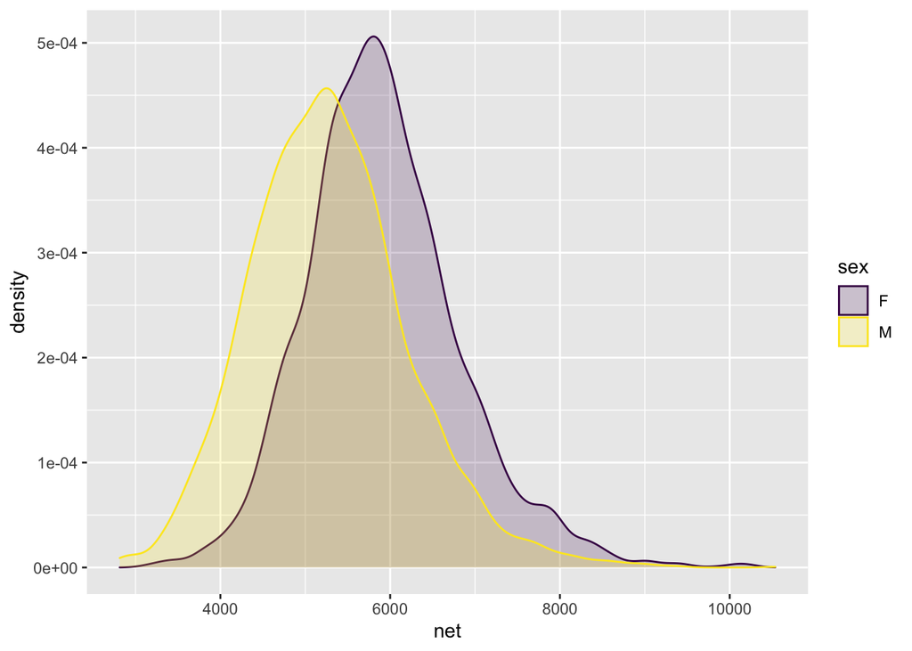

```r
TenMileRace %>% ggplot(aes(x = net, fill = sex, color = sex)) +
  geom_density(alpha = 0.2) +
  scale_color_viridis(discrete = TRUE) +
  scale_fill_viridis(discrete = TRUE)
```

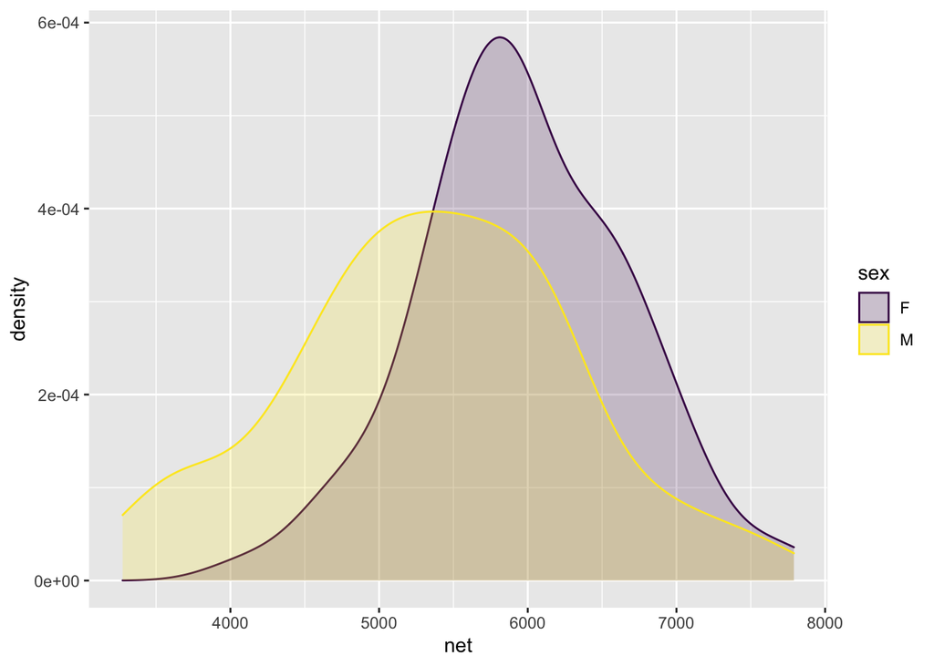

```r
TenMileRace %>%
  slice_sample(n = 160) %>% ggplot(aes(x = net, fill = sex, color = sex)) +
    geom_density(alpha = 0.2) +
    scale_color_viridis(discrete = TRUE) +
    scale_fill_viridis(discrete = TRUE)
```

2. (10 points) Obtain the median of the net race time (start to finish lines) grouped by sex for the entire population and for a random sample of 160 runners.

```r
TenMileRace %>% group_by(sex) %>% summarise(median(net))
```

| sex | median(net) |
| --- | --- |
| F | 5843 |
| M | 5236 |

```r
TenMileRace %>% slice_sample(n = 160) %>% group_by(sex) %>% summarise(median(net))
```

| sex | median(net) |
| --- | --- |
| F | 6001 |
| M | 5144 |

3. (10 points) Obtain a density plot of the medians of the net race times grouped by sex for 500 random samples of 160 runners.

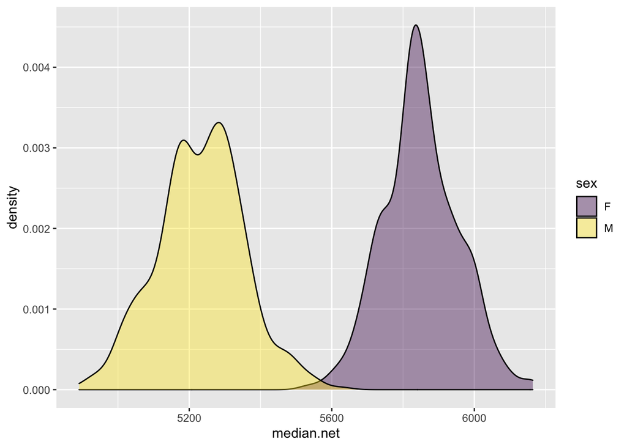

```r
rmedian = function(n0) {
  TenMileRace %>%
    slice_sample(n = n0) %>%
    group_by(sex) %>%
    summarise(n = n(), median.net = median(net))
}

x = tibble(sex = NULL, n = NULL, median.net = NULL)
for (i in 1:500) {
  x = bind_rows(x, rmedian(160))
}
x %>%
  ggplot(aes(x = median.net, fill = sex)) +
  geom_density(alpha = 0.4) +
  scale_color_viridis(discrete = TRUE) +
  scale_fill_viridis(discrete = TRUE)
```

4. (15 points) Obtain the means and standard deviations of the medians of the net race times grouped by sex for 500 random samples of 10, 40, 160, and 640 runners. We illustrated in class the theorem that the standard deviation of the *means* of samples of size $n$ is proportional to $1/\sqrt{n}$. Does the standard deviation of the *medians* of samples of size $n$ appear to be proportional to $1/\sqrt{n}$? Explain.

```r
rstats.of.medians = function(n0) {
  x = tibble(sex = NULL, n = NULL, median.net = NULL)
  for (i in 1:500) {
    x = bind_rows(x, rmedian(n0))
  }
  x %>%
    group_by(sex) %>%
    summarise(n = n0, mean = mean(median.net), sd = sd(median.net), theory = 1/sqrt(n0))}
bind_rows(
  rstats.of.medians(10),
  rstats.of.medians(40),
  rstats.of.medians(160),
  rstats.of.medians(640))
```

| sex | n | mean | sd | theory |
| --- | --- | --- | --- | --- |
| F | 10 | 5825.531 | 438.46993 | 0.31622777 |
| M | 10 | 5242.224 | 463.56664 | 0.31622777 |
| F | 40 | 5848.219 | 218.85034 | 0.15811388 |
| M | 40 | 5226.617 | 232.51667 | 0.15811388 |
| F | 160 | 5840.199 | 109.80464 | 0.07905694 |
| M | 160 | 5225.600 | 119.07951 | 0.07905694 |
| F | 640 | 5842.878 | 52.27529 | 0.03952847 |
| M | 640 | 5233.633 | 56.26534 | 0.03952847 |

### Exercise 3 (30 points)

Let the population be all flips of a fair coin. During class we defined a function that generates a random sample of `n0` fair coin flips and returns the proportion of heads. The following code chunk provides a similar definition and illustrates its use for 12 fair coin flips. Note that the result is returned as a tibble.

```r
rprop = function(n0) {
  rflips = sample(c(0,1), size = n0, replace = TRUE)
  tibble(
    n = n0,
    prop.heads = mean(rflips))
}
rprop(12)
```

| n | prop.heads |
| --- | --- |
| 12 | 0.5833333 |

The *span* of a sequence of `n0` fair coin flips is the maximum length of runs of either tails or heads as a proportion of `n0`. For example, if 110010000010 is a sequence of 12 fair coin flips, then the maximum length of runs of either tails or heads is 5 and its span is $5/12 = 0.41667$.

1. (10 points) Define a function that generates a random sample of `n0` fair coin flips and returns its span as a tibble. Illustrate the use of the function on a sample of 12 fair coin flips.

```r
rspan = function(n0) {
  case = sample(c(0,1), size = n0, replace = TRUE)
  run_length = max(rle(case)$lengths)
  tibble(n = n0, span = run_length/n0)
}
rspan(12)
```

| n | span |
| --- | --- |
| 12 | 0.3333333 |

2. (10 points) Obtain a density plot of the spans for 432 random samples of 100 fair coin flips. Based on this information, how surprised would you be to obtain 10 heads in a row while flipping a penny one hundred times?

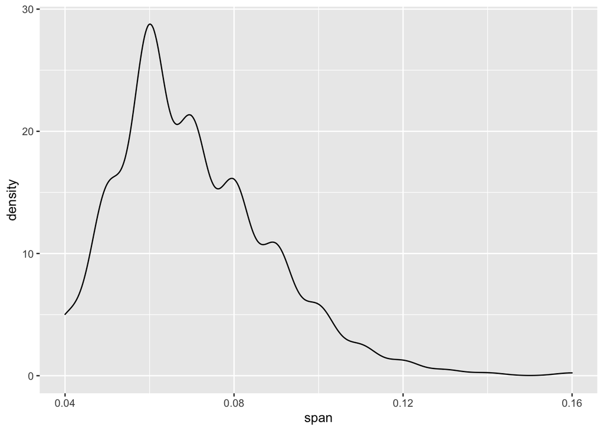

```r
x = tibble(span = NULL)
for (i in 1:432) {
  x = bind_rows(x,rspan(100))
}

x %>% ggplot(aes(x = span)) +
  geom_density()
```

Being a human with a naturally poor concept of randomness, I would probably be somewhat surprised to obtain ten heads in a row in 100 flips, especially on the very first set of 100 flips. However, a ten-head run wouldn’t make me question the fairness of the coin in the way a 20-head run certainly would.

3. (10 points) Obtain the means and standard deviations of the spans for 10,000 random samples of 5, 10, 40, 160, and 640 fair coin flips. We illustrated in class the theorem that the standard deviation of the *means* of samples of size $n$ is proportional to $1/\sqrt{n}$. Does the standard deviation of the *spans* of samples of size $n$ appear to be proportional to $1/\sqrt{n}$? Explain.

```r
rstats.of.spans = function(n0) {
  x = tibble(n = NULL, span = NULL)
  for (i in 1:10000) {
    x = bind_rows(x, rspan(n0))
  }
  x %>%
    summarise(n = n0, mean = mean(span), sd = sd(span), theory = 1/sqrt(n0))}
bind_rows(
  rstats.of.spans(5),
  rstats.of.spans(10),
  rstats.of.spans(40),
  rstats.of.spans(160),
  rstats.of.spans(640))
```

| n | mean | sd | theory |
| --- | --- | --- | --- |
| 5 | 0.53672000 | 0.195774039 | 0.44721360 |
| 10 | 0.36411000 | 0.133359238 | 0.31622777 |
| 40 | 0.14148750 | 0.042873753 | 0.15811388 |
| 160 | 0.04774188 | 0.011205613 | 0.07905694 |
| 640 | 0.01507984 | 0.002871987 | 0.03952847 |